# Sentiment Analysis

Saverio Fontana

2024-03-12

# LOADING PACKAGES

The goal of this project is to perform a Sentiment Analysis on the reviews about three different telephone companies. First of all we load the necessary libraries and some useful functions, pre-trained models and dictionaries.

```r
knitr::opts_chunk$set(echo = TRUE)

library(RedditExtractoR)
library(dplyr)
```

```r
library(ggplot2)
library(tidyr)
library(cld2)
library(cld3)
library(tm)
library(udpipe)
library(rtweet)
library(ngram)
library(wordcloud)
library(openxlsx)
library(stringr)

#Load some useful functions
source("utility.R", local = knitr::knit_global())
#Load functions for sentiment analysis
source("sentimentFunctions.R", local = knitr::knit_global())
## Load a pre-trained model for dictionaries and the lemmatizzation in the italian language (NOTE: this model wa trained by the UD treebank for italian)
un_model_I <- udpipe_load_model("italian-vit-ud-2.5-191206.udpipe")

#Common compound
load("frmComposteOpSy.RData")

#Common stopwords
load("IT_stopwwords.RData")

#Dictionaries for sentiment
load("diz_polarity.RData")
```

**NB that the language of the analysis is Italian**

## Load data

```r
load("dfRecHoEoFw.RData")
summary(dfRecHoEoFw)
```

```
##    company               data                           autore
##  Length:900         Min.   :2023-03-31 17:42:51.00   Length:900
##  Class :character   1st Qu.:2023-05-08 18:38:31.00   Class :character
##  Mode  :character   Median :2023-05-16 12:52:26.00   Mode  :character
##                     Mean   :2023-05-10 02:58:45.60
##                     3rd Qu.:2023-05-19 14:03:32.75
##                     Max.   :2023-05-22 12:49:51.00
##       voto          titolo            commento            testo
##  Min.   :1.000   Length:900         Length:900         Length:900
##  1st Qu.:4.000   Class :character   Class :character   Class :character
##  Median :5.000   Mode  :character   Mode  :character   Mode  :character
##  Mean   :4.097
##  3rd Qu.:5.000
##  Max.   :5.000
```

```r
colnames(dfRecHoEoFw)
```

```
## [1] "company"  "data"     "autore"   "voto"     "titolo"   "commento" "testo"
```

As we can see, for each review we are observing the name of the company reviewed, the data, the author, the mark given, the title, the comment and the text.

# TEXTUAL CLEANING AND CORRECTION OF COMPOUND EXPRESSION

```r
#Clean text
dfRecHoEoFw$txtp <- cleanText(xtxt = dfRecHoEoFw$testo, punctation = T)

#Visualize N-Grams
visNGram(x = dfRecHoEoFw$txtp ,ngrI = 2,ngrF = 4,nn = 50)
```

```r
vcorrez <- c("servizio clienti", NA,
             "il call center", "call_center",
             "call center", NA,
             "velocità di navigazione", "velocità_navigazione",
             "il servizio clienti", "servizio_clienti",
             "problemi di connessione", "problemi_connessione",
             "rapporto qualit  prezzo", NA)

dfRecHoEoFw$txtp <- corFrmComp(dfRecHoEoFw$txtp, correzioni = vcorrez)

visNGram(dfRecHoEoFw$txtp, 2, 4)
dfRecHoEoFw$txtp <- corNGram(dfRecHoEoFw$txtp, verbose=T)
```

## Lemmatization and deleting stopwords

We then proceed with the lemmatization (*i.e. the process of grouping together different inflected forms of the same word*) and the removal of the stopwords (*not significant words like the articles or the preopositions*)

```r
dfRecHoEoFw$doc_id <- 1:nrow(dfRecHoEoFw)
dfRecHoEoFwL <- lemmaUDP(x = dfRecHoEoFw$txtp,
                         model = un_model_I,
                         doc_id = dfRecHoEoFw$doc_id,
                         stopw = stopwIT,
                         userstopw = c("homobile", "eolo", "fastweb"))
```

## Reconstruction of lemmatized sentences

The next step is the recostruction of the sentences with the lemmatized words (*NOTE the use of the left join function*)

```r
txtL <- dfRecHoEoFwL%>%
  mutate(doc_id=as.numeric(doc_id)) %>%
  filter(!is.na(lemma) & STOP==FALSE & upos %in% c("ADJ","NOUN","PROPN","VERB","ADV")) %>%
  group_by(doc_id) %>%
  summarise(txtL=paste(lemma,collapse = " "))

dfRecHoEoFw <- left_join(dfRecHoEoFw, txtL, by="doc_id")
```

# WORDCLOUDS

To find the significant reviews we count lemmas per sentence, and then we select only those sentence with at least 5 lemmas:

```r
nlemmi <- sapply(dfRecHoEoFw$txtL, FUN=wordcount)
#Select sentences with at least 5 lemmas
dfRecHoEoFw_ <- dfRecHoEoFw[nlemmi>4,]
```

First of all, we find the 10 most common lemmas:

```r
dfRecHoEoFw_$txtL <- removeWords(tolower(dfRecHoEoFw_$txtL), words=stopwITwc)
corpL_ <- Corpus(VectorSource(dfRecHoEoFw_$txtL))
tdmL_ <- TermDocumentMatrix(corpL_)
tdmL_M <- as.matrix(tdmL_)     # MATRIX terms-documents

# distribution of frequences of lemmas
dfcorpL_ <- data.frame(words=rownames(tdmL_M),
                       freq=rowSums(tdmL_M)) %>%
  arrange(-freq)
rownames(dfcorpL_) <- NULL
head(dfcorpL_, 10)
```

```
##          words freq
## 1       ottimo  201
## 2     servizio  198
## 3     problema  186
## 4   assistenza  149
## 5    operatore  139
## 6  connessione  112
## 7      tecnico  108
## 8        linea  101
## 9      cliente   90
## 10    internet   89
```

## WORDCLOUD LEMMAS weighted TF (Term Frequency)

We proceed with a visual representation involving the Wordcloud weighted TF.  
This involves representing the most frequently occurring lemmas in the text corpus. The size of each lemma in the word cloud is determined by its weighted term frequency, which measures how often a lemma appears in the corpus.

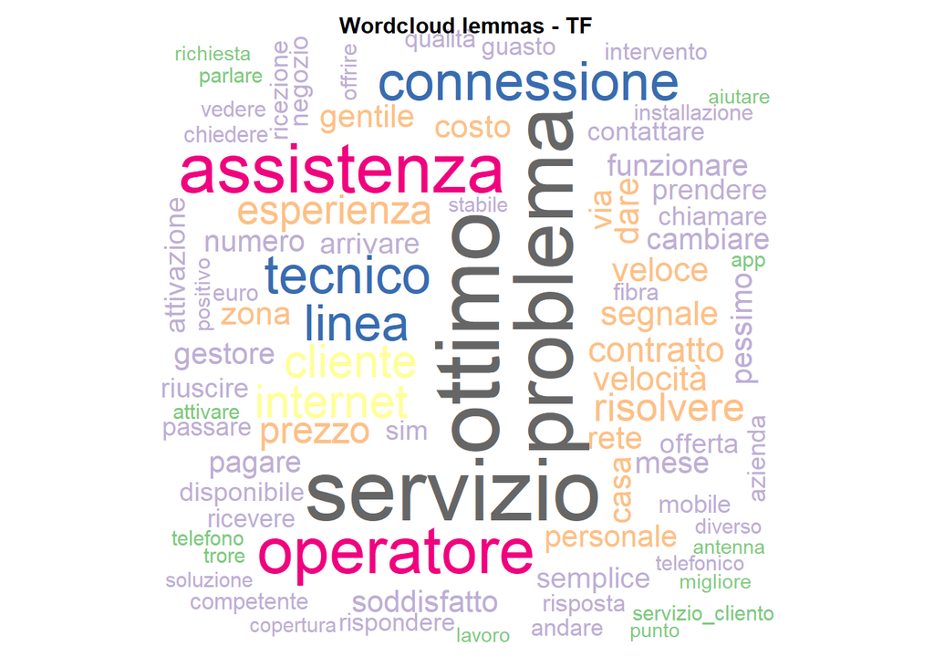

```r
par(mar=c(0,0,0,0))
wordcloud(words = dfcorpL_$words,
          freq = dfcorpL_$freq,
          max.words = 80,
          random.order = FALSE,
          colors = brewer.pal(8, "Accent"))
text(0.5,1,"Wordcloud lemmas - TF",cex=1.,font = 2)
```

## WORDCLOUD LEMMAS weighted TF-IDF –> We add the frequence of the word inside the total corpus of documents

In this case, the size of each lemma in the word cloud is determined by its TF-IDF (*Term Frequency-Inverse Document Frequency*) score.  
It combines term frequency (*TF*), which measures how often a term appears in a document, with inverse document frequency (*IDF*), which penalizes terms that are common across the corpus. This results in a weighting scheme where terms that are frequent in a particular document but rare in the overall corpus are given higher importance.

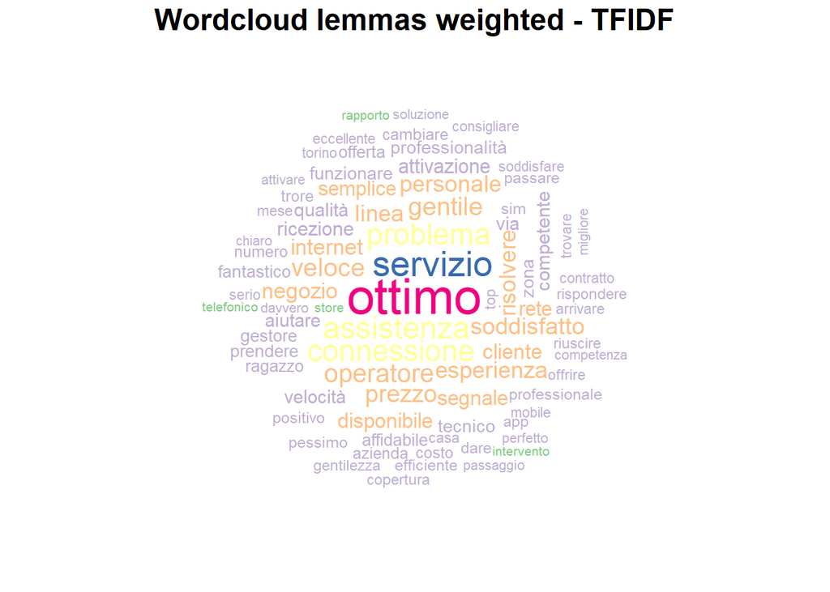

```r
tdmL_IDF <- weightTfIdf(tdmL_)

tdmL_IDFM <- as.matrix(tdmL_IDF)
dfcorpL_IDF <- data.frame(words=rownames(tdmL_IDFM),
                          tdmL_IDFM,
                          freq=rowSums(tdmL_IDFM)) %>%
  arrange(-freq)
rownames(dfcorpL_IDF) <- NULL

par(mar=c(0,0,0,0))
wordcloud(words = dfcorpL_IDF$words,
          freq = dfcorpL_IDF$freq,
          max.words = 80,
          scale = c(2.5,0.3),
          random.order = F,
          colors = brewer.pal(n = 6,name = "Accent"))
text(0.5,1,"Wordcloud lemmas weighted - TFIDF",cex=1.5,font=2)
```

# COMPARISON OF THE COMPANIES

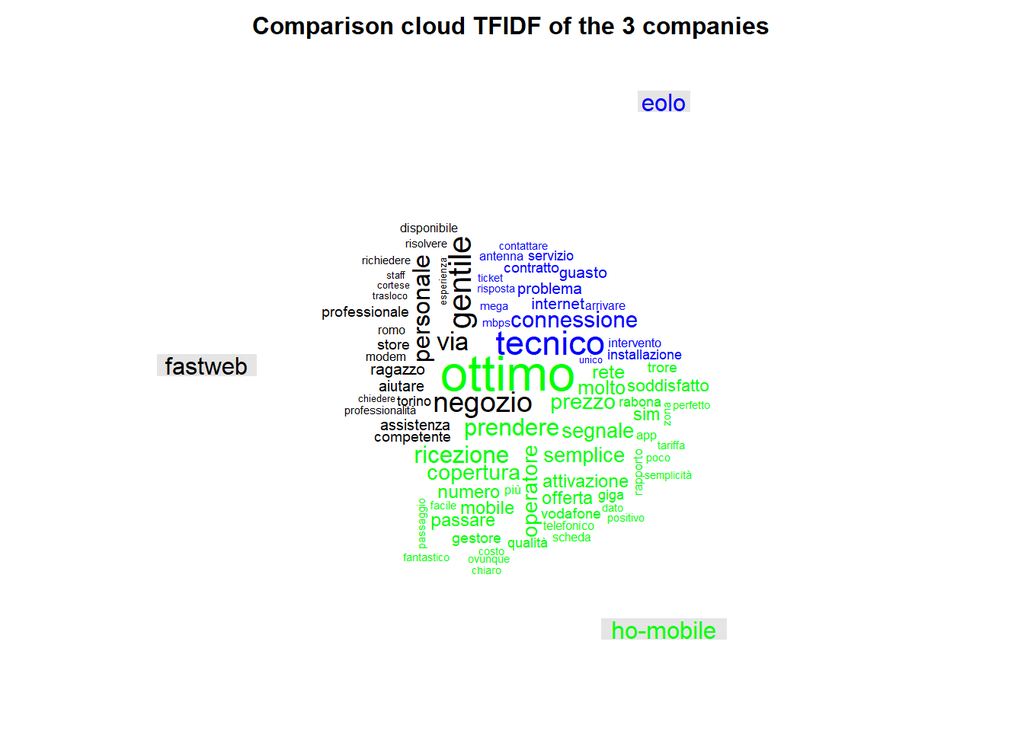

```r
dfRecHoEoFw.company <- dfRecHoEoFw %>%
  group_by(company) %>%
  summarise(txt=paste(txtL,collapse = " "))
corpL.company <- Corpus(VectorSource(dfRecHoEoFw.company$txt))
tdmL.company <- TermDocumentMatrix(corpL.company)

tdmLIDF.company <- weightTfIdf(tdmL.company)
tdmL.companyM <- as.matrix(tdmL.company)
colnames(tdmL.companyM) <- dfRecHoEoFw.company$company

par(mar=c(0,0,0,0))
comparison.cloud(term.matrix = tdmL.companyM,
                 scale = c(2,0.2),
                 max.words = 80,
                 colors = c("Blue","Black","Green"),
                 match.colors = T,
                 title.size = 1)
text(0.5,1,"Comparison cloud TFIDF of the 3 companies",font=2)
```

# SENTIMENT

## Sentiment Score

Now we will compute the Average Sentiment Score using the sentiment dictionaries: SYUZHET, OPENR, NCR.

```r
lDizSent <- list(Syuzhet = dSyuzB, OpenR = dOpenR, NCR = dNcr)

dfRecHoEoFwLPOL <- sentiMediaDiz(x = dfRecHoEoFwL,           # output dof the lemmatization
                                 dict = lDizSent,              # dict to use
                                 negators = polarityShifter,
                                 amplifiers = intensifier,
                                 deamplifiers = weakener)
```

```
## [1] "Syuzhet"
## [1] "OpenR"
## [1] "NCR"
```

```r
dfRecHoEoFwLPOL$DizioPol
```

```
## # A tibble: 898 × 4
##    doc_id    NCR  OpenR Syuzhet
##     <dbl>  <dbl>  <dbl>   <dbl>
##  1      1  0.905  0.905   0.995
##  2     10  0.462 -0.462  -0.462
##  3    100  0      0.462   0.762
##  4    101  0.905  0.905   0.905
##  5    102  0.462  0.762   0.762
##  6    103  0      0.762   0.762
##  7    104  0      0.964   0.762
##  8    105  0.462  0.462   0.762
##  9    106 -0.462  0       0.462
## 10    107  0.716  0.716   0.947
## # ℹ 888 more rows
```

```r
dfRecHoEoFwLPOL$MediaPol
```

```
## # A tibble: 898 × 2
##    doc_id mediaSent
##     <dbl>     <dbl>
##  1      1     0.935
##  2     10    -0.154
##  3    100     0.408
##  4    101     0.905
##  5    102     0.662
##  6    103     0.508
##  7    104     0.575
##  8    105     0.562
##  9    106     0
## 10    107     0.793
## # ℹ 888 more rows
```

```r
#Add the Average Score of Sentiment to the dataframe
dfRecHoEoFw_Sent <- left_join(dfRecHoEoFw_,
                              dfRecHoEoFwLPOL$MediaPol,
                              by="doc_id")

#Computing class of polarity
dfRecHoEoFw_Sent$cl_mediaPol <- ifelse(dfRecHoEoFw_Sent$mediaSent<0,
                                       "Negative",
                                       ifelse(dfRecHoEoFw_Sent$mediaSent>0,
                                              "Positive",
                                              "Neutral"))
```

## Average scores and graphics

```r
#Total mean of sentiment score
mean(dfRecHoEoFw_Sent$mediaSent)
```

```
## [1] 0.3885124
```

```r
#Average sentiment score grouped by company
dfRecHoEoFw_Sent %>% group_by(company) %>%
  summarise(mean(mediaSent))
```

```
## # A tibble: 3 × 2
##   company   `mean(mediaSent)`
##   <chr>                 <dbl>
## 1 eolo                  0.332
## 2 fastweb               0.408
## 3 ho-mobile             0.440
```

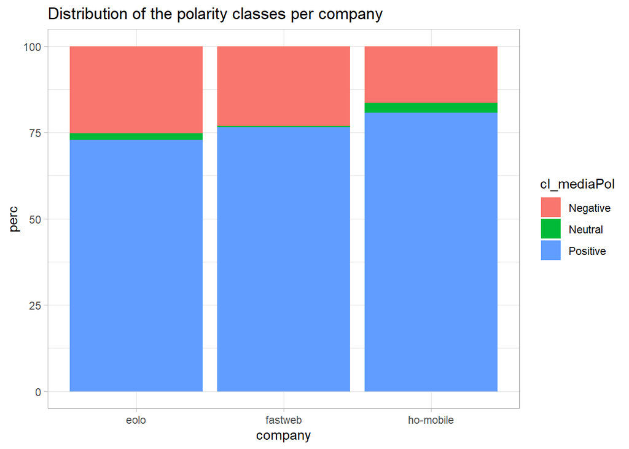

```r
#Distribution of the class of polarity divided per company
dfRecHoEoFw_Sent %>% group_by(company,cl_mediaPol) %>%
  summarise(n=n()) %>%
  mutate(perc=n/sum(n)*100) %>%
  ggplot(aes(x=company,
             y=perc,
             fill=cl_mediaPol))+
  geom_col()+
  theme_light()+
  ggtitle("Distribution of the polarity classes per company")
```

## Comparison cloud with Negative and Positive

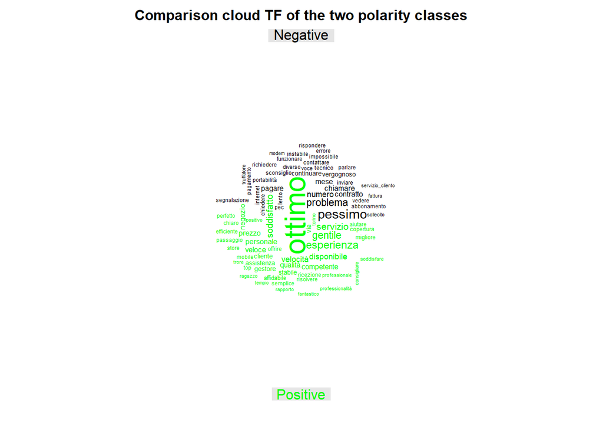

```r
dfRecHoEoFw_polar <- dfRecHoEoFw_Sent %>%
  group_by(cl_mediaPol) %>%
  summarise(txt=paste(txtL,collapse = " "))
corpL.polar <- Corpus(VectorSource(dfRecHoEoFw_polar$txt))
tdmL.polar <- TermDocumentMatrix(corpL.polar)
tdmL.polarM <- as.matrix(tdmL.polar)
colnames(tdmL.polarM) <- dfRecHoEoFw_polar$cl_mediaPol

par(mar=c(0,0,0,0))
comparison.cloud(term.matrix = tdmL.polarM[,c(1,3)],
                 scale = c(2,0.2),
                 max.words = 80,
                 colors = c("Black","green"),
                 match.colors = T,
                 title.size = 1)
text(0.5,1,"Comparison cloud TF of the two polarity classes",font=2)
```

## Comparing grade and polarity classes

```r
#Defining grade classes
dfRecHoEoFw_Sent$cl_voto <- cut(dfRecHoEoFw_Sent$voto,
                                breaks = c(1,2,3,5),
                                include.lowest = T)

#table to compare grade classes and polarity
tabvp <- table(dfRecHoEoFw_Sent$cl_voto, dfRecHoEoFw_Sent$cl_mediaPol)
addmargins(tabvp)
```

```
##
##         Negative Neutral Positive Sum
##   [1,2]       93       3       56 152
##   (2,3]       12       3       17  32
##   (3,5]       40       6      434 480
##   Sum        145      12      507 664
```

```r
sum(diag(tabvp))/sum(tabvp)    #accuracy
```

```
## [1] 0.7981928
```

## Emotions Distributions

```r
dfRecHoEoFw_emo <- myClassEmotion(textColumns = dfRecHoEoFw_$txtL,
                                  algorithm = "bayes",
                                  lexicon = "emotions_it_lem.csv")
dfRecHoEoFw_emo$documenti
```

```r
dfRecHoEoFw_emo$documenti %>% group_by(best_fit) %>%
  summarise(n=n()) %>%
  mutate(perc=n/sum(n)*100)
```

```
## # A tibble: 8 × 3
##   best_fit      n   perc
##   <chr>     <int>  <dbl>
## 1 NC          364 54.8
## 2 disgusto      2  0.301
## 3 gioia       196 29.5
## 4 mix          43  6.48
## 5 paura         8  1.20
## 6 rabbia        5  0.753
## 7 sorpresa     26  3.92
## 8 tristezza    20  3.01
```

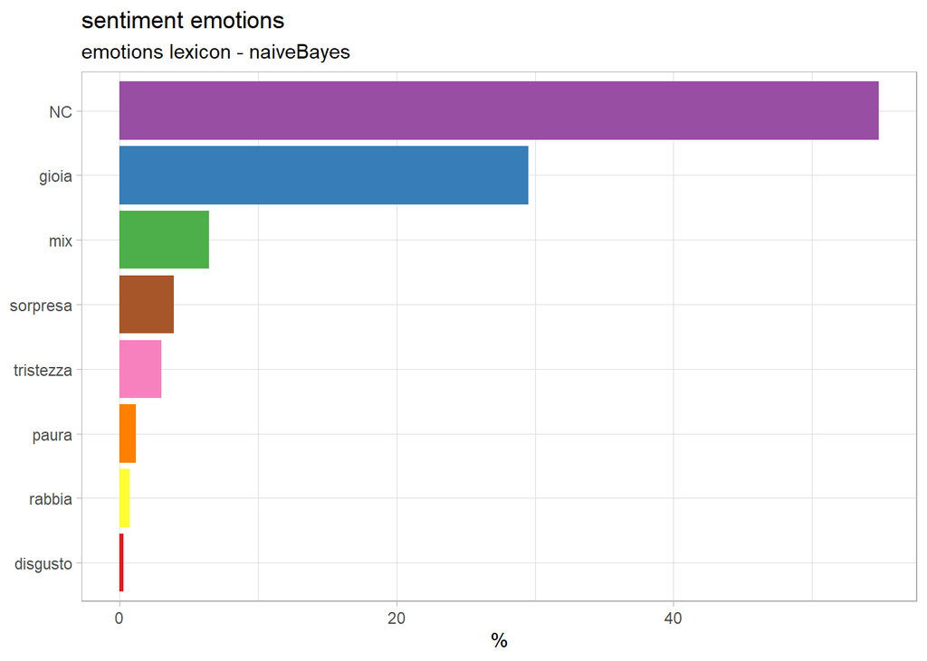

```r
dfRecHoEoFw_emo$documenti %>% group_by(best_fit) %>%
  summarise(n=n()) %>%
  mutate(perc=n/sum(n)*100) %>%
  ggplot(aes(x=reorder(best_fit,perc),
             y=perc,
             fill=best_fit))+
  geom_col()+
  theme_light()+
  scale_fill_brewer(palette = "Set1")+
  coord_flip()+
  labs(title = "sentiment emotions",
       subtitle = "emotions lexicon - naiveBayes")+
  theme(legend.position = "none")+
  xlab(NULL)+
  ylab("%")
```

THE END